# Skyine Analysis - AgZero Mix Experiment

Peter Levy

This document describes the statistical analysis of the skyline data from the AgZero mix (biochar and rockdust) experiment.

## 1 Ensuring balance over time in the data set

First we define a function to expand the data set to a complete 4-hourly time series, so that every chamber has a record for every 4-hour interval.

```r
gmean <- function(x) {
  exp(mean(log(x), na.rm = TRUE))
}

expand_to_complete_ts <- function(
  dt,
  cols = c(
    "datect",
    "trmt_id",
    "chamber_id",
    "f"
  )
) {
  dt_trmt_id <- dt[, .(trmt_id = unique(trmt_id)), by = chamber_id]

  # get complete time series of hourly data for PPFD_IN and dTA
  # start on first full day, end on last full day
  start_ts <- round_date(min(dt$datect), "day") + days(1)
  end_ts <- round_date(max(dt$datect), "day") - days(1)
  # generate a sequence of POSIXct values with a 1 hour interval
  v_date_byhour <- seq(from = start_ts, to = end_ts, by = "1 hour")

  # number of chambers
  n_chamber <- length(unique(dt$chamber_id))
  # final length should be equal this:
  length(v_date_byhour) * n_chamber
  # create chamber_id column
  v_chamber_id <- rep(unique(dt$chamber_id), each = length(v_date_byhour))
  v_trmt_id <- dt_trmt_id$trmt_id[match(v_chamber_id, dt_trmt_id$chamber_id)]

  # repeat the sequence for each chamber
  v_date_byhour <- rep(v_date_byhour, n_chamber)
  dt_time <- data.table(date_byhour = v_date_byhour, chamber_id = v_chamber_id, trmt_id = v_trmt_id)

  # merge hourly time sequence with desired columns of raw data
  # round time to nearest hour so we can merge with complete time series
  dt[, datect := lubridate::round_date(datect, "hour")]
  # cols <- c("date_byhour", "chamber_id", "PPFD_IN", "dTA", "VWC", "f_co2", "lue", "R_10", "k_T")
  dt <- dt[, ..cols][
    dt_time,
    on = .(datect = date_byhour, chamber_id = chamber_id, trmt_id = trmt_id)
  ]
  setnames(dt, "datect", "date")
  dt <- setDT(timeAverage(drop_units(dt), avg.time = "4 hour", type = c("chamber_id", "trmt_id")))
  dt[, block_id := as.factor(1 + floor(as.numeric(chamber_id) / 5 - 0.2))]
  dt[, f_trmt_mean := mean(f, na.rm = TRUE), by = .(date, trmt_id)]
  dt[is.na(f), f := f_trmt_mean]
  return(dt)
}
```

We check the balance in the raw data.

```
##
##      FALSE
##   1      0
##   2    567
##   3    568
##   4    558
##   5      0
##   6    544
##   7      0
##   8    539
##   9    548
##   10   549
##   11   558
##   12   574
##   13     0
```

[output cut: 23 more lines]

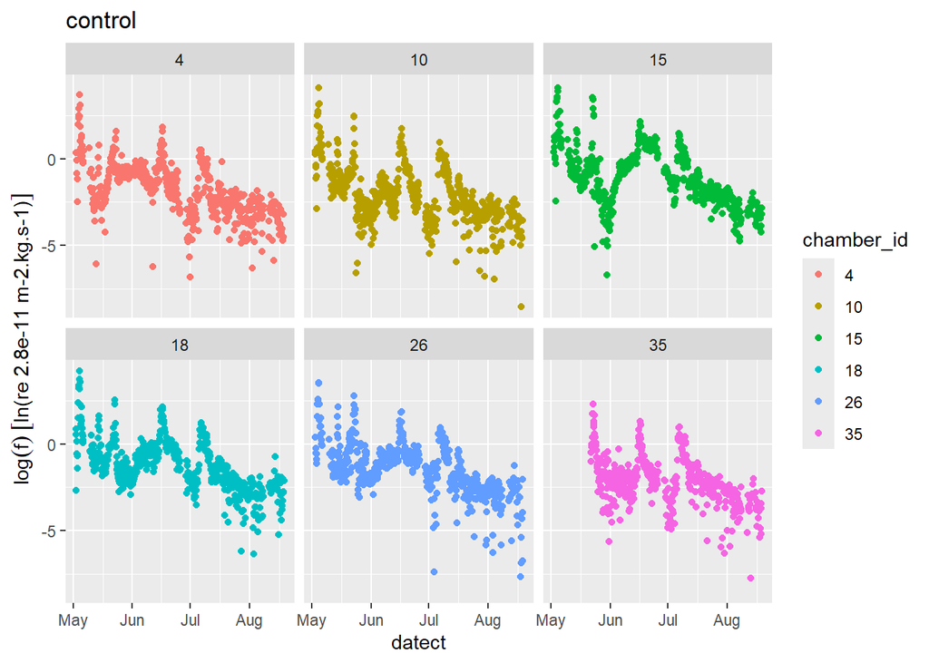

Time series of N2O flux in control treatment.

Chamber 35 in the control (above) is missing the initial fertilisation event so the mean will appear very low. The biochar 1 (below) and other treatments appear to be ok - no gaps that would strongly sway the average.

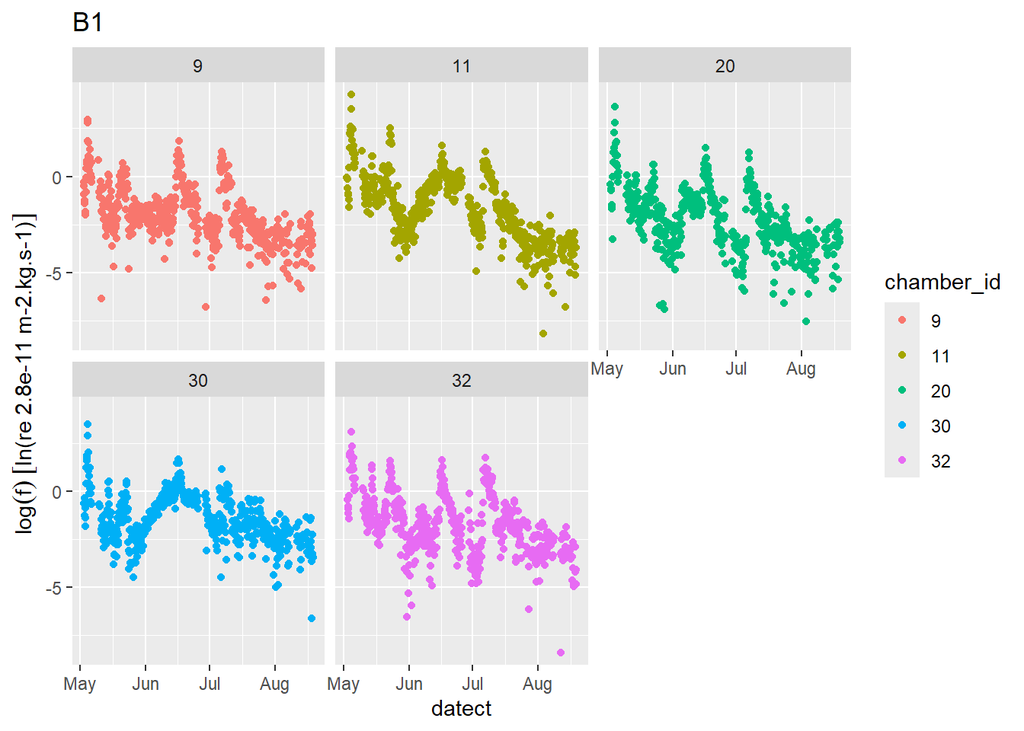

Time series of N2O flux in biochar 1 treatment.

We can enforce balance in the data by filling in any gaps in the 4-hour data with the treatment mean (i.e. the mean of the other chambers in the treatment for the corresponding 4-hour interval).

```r
dt <- expand_to_complete_ts(dt)
```

We then check the balance again in the gap-filled data.

```
##
##      FALSE TRUE
##   2    582   61
##   3    582   61
##   4    582   61
##   6    582   61
##   8    582   61
##   9    578   65
##   10   582   61
##   11   578   65
##   12   582   61
##   15   582   61
##   17   582   61
##   18   582   61
##   19   582   61
##   20   578   65
##   23   582   61
##   24   582   61
##   26   582   61
##   29   582   61
##   30   578   65
##   31   582   61
##   32   578   65
##   33   582   61
##   35   582   61
```

Balance is restored.

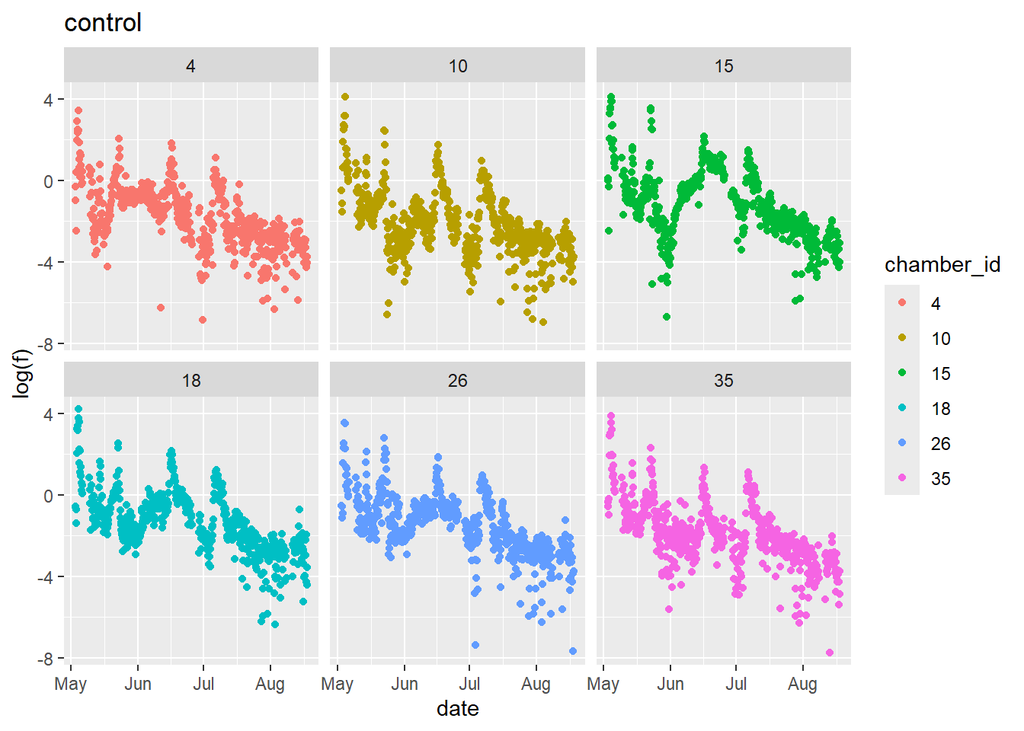

Time series of N2O flux in gap-filled control treatment.

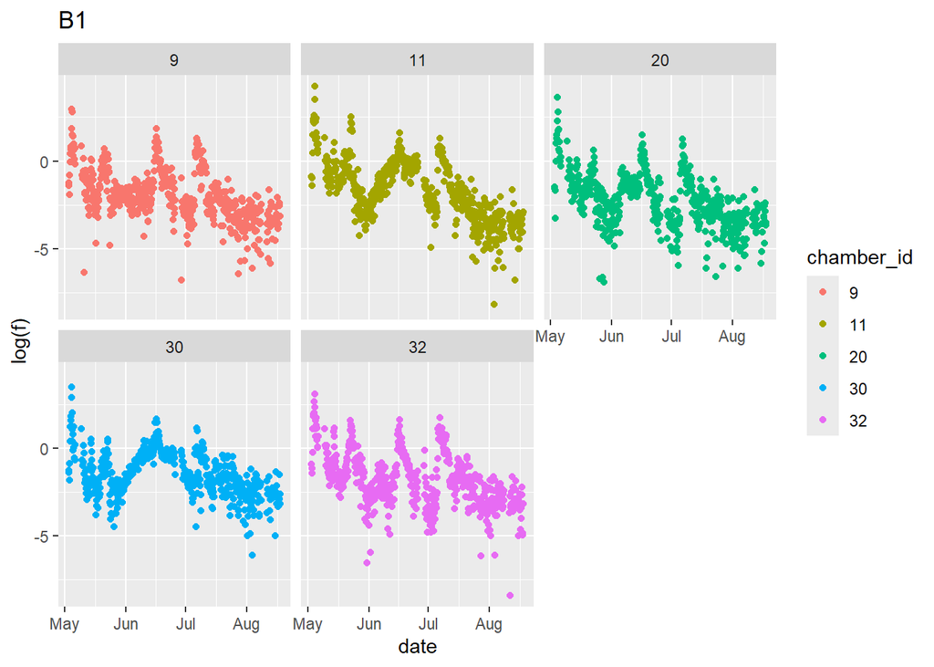

Time series of N2O flux in gap-filled biochar 1 treatment.

## 2 Analysis on the log-transformed data

We then repeat the analysis on the log-transformed data, but add a blocking term. Remembering that this estimates the median (or geometric mean) rather than the arithmetic mean (which is what we want), we back-transform to get fluxes on the original scale, but an additional calculation is needed to estimate the arithmetic mean.

To do this we fit a linear mixed model to the logged data, of the form below:

```r
m_lmer <- lmer(log(f) ~ trmt_id + (1 | block_id) + (1 | chamber_id), data = dt)
```

Obtaining estimates of the treatment effects and intervals in his way, we then apply the back-transformation and calculate the arithmetic means and intervals with the standard equation for the lognormal distribution:

$$\mu = exp(\mu_{\mathrm{log}} + \sigma_{\mathrm{log}}^2 / 2)$$

where $\mu$ is the arithmetic mean on the original scale, $\mu_{\mathrm{log}}$ is the mean of the log-transformed data and $\sigma_{\mathrm{log}}$ is the standard deviation of the log-transformed data.

```
## Linear mixed model fit by REML ['lmerMod']
## Formula: log(f) ~ trmt_id + (1 | block_id) + (1 | chamber_id)
##    Data: dt
##
## REML criterion at convergence: 47564.8
##
## Scaled residuals:
##     Min      1Q  Median      3Q     Max
## -6.8285 -0.6353 -0.0472  0.6261  4.3217
##
## Random effects:
##  Groups     Name        Variance Std.Dev.
##  chamber_id (Intercept) 0.086052 0.29335
##  block_id   (Intercept) 0.008271 0.09094
##  Residual               2.043581 1.42954
## Number of obs: 13366, groups:  chamber_id, 23; block_id, 5
##
## Fixed effects:
##             Estimate Std. Error t value
## (Intercept)  -1.6149     0.1293 -12.491
## trmt_idB1    -0.2405     0.1818  -1.323
## trmt_idB2     0.1218     0.1677   0.726
## trmt_idRD     0.1528     0.1854   0.824
##
## Correlation of Fixed Effects:
##           (Intr) trm_B1 trm_B2
## trmt_idB1 -0.632
## trmt_idB2 -0.697  0.484
## trmt_idRD -0.637  0.432  0.499
## $emmeans
##  trmt_id emmean    SE  df asymp.LCL asymp.UCL
##  control  -1.61 0.129 Inf     -1.87     -1.36
##  B1       -1.86 0.142 Inf     -2.13     -1.58
##  B2       -1.49 0.121 Inf     -1.73     -1.26
##  RD       -1.46 0.143 Inf     -1.74     -1.18
##
## Degrees-of-freedom method: asymptotic
## Results are given on the log (not the response) scale.
## Confidence level used: 0.95
##
## $contrasts
##  contrast     estimate    SE  df z.ratio p.value
##  control - B1    0.240 0.182 Inf   1.323  0.5484
##  control - B2   -0.122 0.168 Inf  -0.726  0.8865
##  control - RD   -0.153 0.185 Inf  -0.824  0.8431
##  B1 - B2        -0.362 0.178 Inf  -2.035  0.1750
##  B1 - RD        -0.393 0.196 Inf  -2.009  0.1844
##  B2 - RD        -0.031 0.177 Inf  -0.175  0.9981
##
## Degrees-of-freedom method: asymptotic
## Results are given on the log (not the response) scale.
## P value adjustment: tukey method for comparing a family of 4 estimates
```

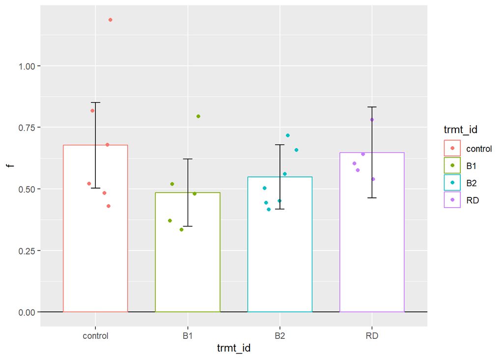

Effect of treatments on N2O flux (arithmetic means), showing 95% confidence intervals estimated from a linear mixed-effect model fitted to the log-transformed data. Results are back-transformed to the original scale and the arithmetic mean calculated according to the standard equation.

```
## Linear mixed-effects model fit by REML
##   Data: drop_units(dt)
##        AIC      BIC    logLik
##   47577.05 47622.05 -23782.53
##
## Random effects:
##  Formula: ~1 | chamber_id
##         (Intercept) Residual
## StdDev:   0.3059294 1.429539
##
## Fixed effects:  log(f) ~ trmt_id
##                  Value Std.Error    DF    t-value p-value
## (Intercept) -1.6130690 0.1272164 13343 -12.679722  0.0000
## trmt_idB1   -0.2261494 0.1887053    19  -1.198426  0.2455
## trmt_idB2    0.1192735 0.1733668    19   0.687984  0.4998
## trmt_idRD    0.1354009 0.1886925    19   0.717574  0.4817
##  Correlation:
##           (Intr) trm_B1 trm_B2
## trmt_idB1 -0.674
## trmt_idB2 -0.734  0.495
## trmt_idRD -0.674  0.455  0.495
##
## Standardized Within-Group Residuals:
##         Min          Q1         Med          Q3         Max
## -6.82604167 -0.63527868 -0.04737081  0.62584141  4.32293607
##
## Number of Observations: 13366
## Number of Groups: 23
## Linear mixed-effects model fit by REML
##   Data: drop_units(dt)
##        AIC      BIC    logLik
##   47578.83 47631.33 -23782.41
##
## Random effects:
##  Formula: ~1 | block_id
##         (Intercept)
## StdDev:   0.0909943
##
##  Formula: ~1 | chamber_id %in% block_id
##         (Intercept) Residual
## StdDev:   0.2933389 1.429539
##
## Fixed effects:  log(f) ~ trmt_id
##                  Value Std.Error    DF    t-value p-value
## (Intercept) -1.6148717 0.1292856 13343 -12.490733  0.0000
## trmt_idB1   -0.2405046 0.1818110    15  -1.322827  0.2057
## trmt_idB2    0.1218175 0.1676719    15   0.726523  0.4787
## trmt_idRD    0.1528321 0.1854230    15   0.824235  0.4227
##  Correlation:
##           (Intr) trm_B1 trm_B2
## trmt_idB1 -0.632
## trmt_idB2 -0.697  0.484
## trmt_idRD -0.637  0.432  0.499
##
## Standardized Within-Group Residuals:
##         Min          Q1         Med          Q3         Max
## -6.82847745 -0.63533179 -0.04721694  0.62611744  4.32167562
##
## Number of Observations: 13366
## Number of Groups:
##                 block_id chamber_id %in% block_id
##                        5                       23
```

As model diagnostic checks, we should check that there is no trend in the residuals, and that they are approximately normally distributed. Both of these seem resonable in the plots below.

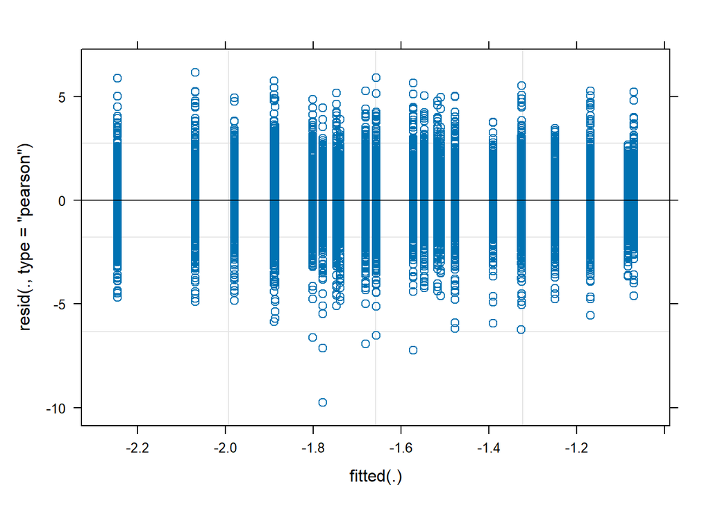

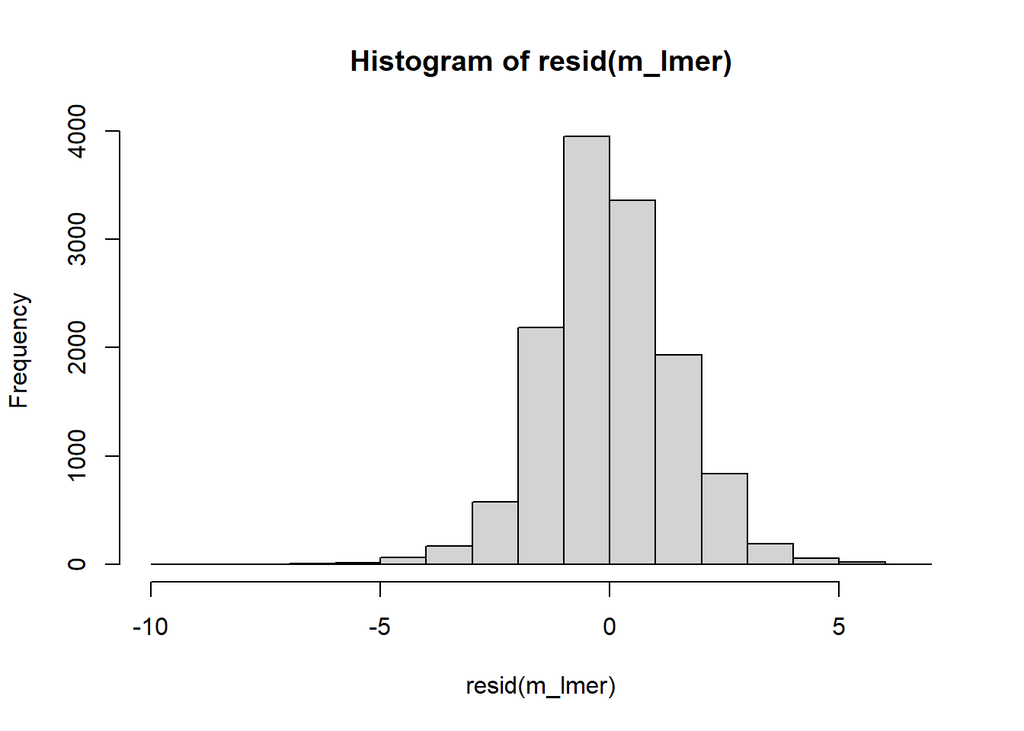

## 3 Calculation of emission factors

The emission factors are calculated for each treatment as the ratio of the cumulative N2O flux to the amount of N applied to the crop. The cumulative N2O flux is simply the product of the mean flux and the length of the time period. N fertiliser was applied in two events with 50 and 75 kg N / ha in each.

Cumulative emissions in mg N / m^2:

```r
dt[, f := set_units(f, nmol_n2o / m^2 / s)]
time_period <- difftime("2024-08-14", "2024-05-03", units = "secs")
time_period <- set_units(as.numeric(time_period), s)
dt[, f := f * time_period]
dt[, f := set_units(f, mg / m^2)] # this is mass of N, not N2O because we define mol_n2o as such
dt[, mean(f), by = trmt_id]
```

```
##    trmt_id                V1
##     <fctr>           <units>
## 1:      B2 128.0371 [mg/m^2]
## 2:      RD 188.3140 [mg/m^2]
## 3: control 211.6131 [mg/m^2]
## 4:      B1 136.3821 [mg/m^2]
```

Emission factors as percentages:

```r
dt[, N_appl := set_units(50 + 75, kg / ha)]
dt[, N_appl := set_units(N_appl, mg / m^2)]
dt[, ef := f / N_appl] # back to N2, not N2O
dt[, mean(ef) * 100, by = trmt_id]
```

```
##    trmt_id           V1
##     <fctr>      <units>
## 1:      B2 1.024297 [1]
## 2:      RD 1.506512 [1]
## 3: control 1.692905 [1]
## 4:      B1 1.091057 [1]
```